# 20250318HTML

Krzysztof Stawarz

2025-03-25

```r
library(tidyverse)
library(knitr)
```

## a) wczytaj dane kosmos, ale nie wyświetlaj tego kodu

korzystając z dplyr:

## b) wybierz z bazy tylko respondentów z PL

## c) wybierz z bazy tylko zmienne `sdg.imp` oraz `gender`, `age`, `edu.level` i `edu.field`

```r
dim(df)
```

```
## [1] 2178  129
```

```r
names(df)
```

```
##   [1] "StartDate"             "EndDate"               "Status"
##   [4] "Progress"              "Duration__in_seconds_" "Finished"
##   [7] "RecordedDate"          "ResponseId"            "DistributionChannel"
##  [10] "UserLanguage"          "consent"               "gender"
##  [13] "age"                   "edu.level"             "edu.field"
##  [16] "nationality"           "city"                  "political.1"
##  [19] "political.2"           "political.3"           "religiousity"
##  [22] "prior.1"               "prior.2"               "prior.3"
##  [25] "prior.4"               "prior.5"               "prior.6"
##  [28] "prior_6_1_TEXT"        "attitude.1"            "attitude.2"
##  [31] "value.1"               "value.2"               "value.3"
##  [34] "value.4"               "value.5"               "value.6"
##  [37] "value.7"               "value.8"               "value.9"
##  [40] "value.10"              "value.11"              "value.12"
##  [43] "att.check.five"        "expectancy.1"          "expectancy.2"
```

[output cut: 28 more lines]

```r
unique(df$UserLanguage) # to kryterium wydaje się ok żeby oceniać skąd są badani
```

```
## [1] "PL"    "EN-GB" "EN"
```

```r
df <- df %>%
  filter(UserLanguage == "PL") %>%
  select(age, gender, edu.level, edu.field, matches("^sdg.imp\\.\\d+$"))

dim(df)
```

```
## [1] 1052   20
```

```r
names(df)
```

```
##  [1] "age"        "gender"     "edu.level"  "edu.field"  "sdg.imp.1"
##  [6] "sdg.imp.2"  "sdg.imp.3"  "sdg.imp.4"  "sdg.imp.5"  "sdg.imp.6"
## [11] "sdg.imp.7"  "sdg.imp.8"  "sdg.imp.9"  "sdg.imp.10" "sdg.imp.11"
## [16] "sdg.imp.12" "sdg.imp.13" "sdg.imp.14" "sdg.imp.15" "sdg.imp.16"
```

```r
df$gender <- factor(df$gender,
                    levels = c(1, 2, 3, 4),
                    labels = c("kobieta", "mężczyzna", "inna", "wolę nie odpowiadać"))

df$edu.level <- factor(df$edu.level,
                       levels = c(1, 2, 3),
                       labels = c("podstawowe", "średnie", "wyższe"))

df$edu.field <- factor(df$edu.field,
                       levels = c(1, 2, 3, 4),
                       labels = c("humanistyczne lub społeczne",
                                  "ścisłe lub techniczne",
                                  "biologiczne lub medyczne",
                                  "nie dotyczy"))
```

## d) korzystając ze znanych Ci funkcji statystycznych wykonaj przynajmniej 3 analizy:

### 1) statystyki opisowej / statystyk opisowych (np. miary tendencji centralnej, miary rozproszenia itp.)

```r
summary(df)
```

```
##       age                        gender         edu.level
##  Min.   :18.00   kobieta            :545   podstawowe: 51
##  1st Qu.:30.00   mężczyzna          :503   średnie   :592
##  Median :41.00   inna               :  1   wyższe    :409
##  Mean   :41.19   wolę nie odpowiadać:  3
##  3rd Qu.:52.00
##  Max.   :66.00
##                        edu.field     sdg.imp.1       sdg.imp.2
##  humanistyczne lub społeczne:195   Min.   :1.000   Min.   :1.000
##  ścisłe lub techniczne      :296   1st Qu.:4.000   1st Qu.:4.000
##  biologiczne lub medyczne   : 60   Median :4.000   Median :4.000
##  nie dotyczy                :501   Mean   :4.629   Mean   :4.663
##                                    3rd Qu.:6.000   3rd Qu.:6.000
##                                    Max.   :7.000   Max.   :7.000
##    sdg.imp.3       sdg.imp.4       sdg.imp.5       sdg.imp.6      sdg.imp.7
##  Min.   :1.000   Min.   :1.000   Min.   :1.000   Min.   :1.00   Min.   :1.00
##  1st Qu.:4.000   1st Qu.:4.000   1st Qu.:4.000   1st Qu.:4.00   1st Qu.:4.00
##  Median :5.000   Median :5.000   Median :4.000   Median :5.00   Median :5.00
##  Mean   :4.925   Mean   :5.181   Mean   :4.711   Mean   :5.07   Mean   :5.33
##  3rd Qu.:7.000   3rd Qu.:7.000   3rd Qu.:6.000   3rd Qu.:7.00   3rd Qu.:7.00
##  Max.   :7.000   Max.   :7.000   Max.   :7.000   Max.   :7.00   Max.   :7.00
##    sdg.imp.8       sdg.imp.9      sdg.imp.10      sdg.imp.11      sdg.imp.12
##  Min.   :1.000   Min.   :1.00   Min.   :1.000   Min.   :1.000   Min.   :1.000
##  1st Qu.:4.000   1st Qu.:4.75   1st Qu.:4.000   1st Qu.:4.000   1st Qu.:4.000
##  Median :5.000   Median :6.00   Median :4.000   Median :5.000   Median :5.000
##  Mean   :5.171   Mean   :5.44   Mean   :4.606   Mean   :4.767   Mean   :4.761
##  3rd Qu.:7.000   3rd Qu.:7.00   3rd Qu.:6.000   3rd Qu.:6.000   3rd Qu.:6.000
##  Max.   :7.000   Max.   :7.00   Max.   :7.000   Max.   :7.000   Max.   :7.000
##    sdg.imp.13      sdg.imp.14      sdg.imp.15      sdg.imp.16
##  Min.   :1.000   Min.   :1.000   Min.   :1.000   Min.   :1.000
##  1st Qu.:4.000   1st Qu.:4.000   1st Qu.:4.000   1st Qu.:4.000
##  Median :5.000   Median :4.000   Median :5.000   Median :5.000
##  Mean   :5.188   Mean   :4.434   Mean   :5.038   Mean   :4.829
##  3rd Qu.:7.000   3rd Qu.:5.000   3rd Qu.:6.000   3rd Qu.:6.000
##  Max.   :7.000   Max.   :7.000   Max.   :7.000   Max.   :7.000
```

```r
df_summary <-   df %>%
    summarise(across(
      where(is.numeric),
      list(
        Min = min,
        Q1 = ~quantile(., 0.25),
        Median = median,
        Q3 = ~quantile(., 0.75),
        Max = max,
        Mean = mean,
        SD = sd,
        Mode = DescTools::Mode
      ),
      .names = "{.col}_{.fn}"
    )) %>%
    pivot_longer(everything(),
                 names_to = c("Variable", "Statistic"),
                 names_sep = "_") %>%
    pivot_wider(names_from = Statistic, values_from = value)
kable(df_summary, digits = 2, caption = "Summary Statistics Table")
```

Summary Statistics Table

| Variable | Min | Q1 | Median | Q3 | Max | Mean | SD | Mode |
| --- | --- | --- | --- | --- | --- | --- | --- | --- |
| age | 18 | 30.00 | 41 | 52 | 66 | 41.19 | 12.91 | 43 |
| sdg.imp.1 | 1 | 4.00 | 4 | 6 | 7 | 4.63 | 1.75 | 4 |
| sdg.imp.2 | 1 | 4.00 | 4 | 6 | 7 | 4.66 | 1.78 | 4 |
| sdg.imp.3 | 1 | 4.00 | 5 | 7 | 7 | 4.92 | 1.66 | 4 |
| sdg.imp.4 | 1 | 4.00 | 5 | 7 | 7 | 5.18 | 1.52 | 7 |
| sdg.imp.5 | 1 | 4.00 | 4 | 6 | 7 | 4.71 | 1.68 | 4 |
| sdg.imp.6 | 1 | 4.00 | 5 | 7 | 7 | 5.07 | 1.64 | 7 |
| sdg.imp.7 | 1 | 4.00 | 5 | 7 | 7 | 5.33 | 1.50 | 7 |
| sdg.imp.8 | 1 | 4.00 | 5 | 7 | 7 | 5.17 | 1.52 | 7 |
| sdg.imp.9 | 1 | 4.75 | 6 | 7 | 7 | 5.44 | 1.44 | 7 |
| sdg.imp.10 | 1 | 4.00 | 4 | 6 | 7 | 4.61 | 1.67 | 4 |
| sdg.imp.11 | 1 | 4.00 | 5 | 6 | 7 | 4.77 | 1.62 | 4 |
| sdg.imp.12 | 1 | 4.00 | 5 | 6 | 7 | 4.76 | 1.65 | 4 |
| sdg.imp.13 | 1 | 4.00 | 5 | 7 | 7 | 5.19 | 1.58 | 7 |
| sdg.imp.14 | 1 | 4.00 | 4 | 5 | 7 | 4.43 | 1.60 | 4 |
| sdg.imp.15 | 1 | 4.00 | 5 | 6 | 7 | 5.04 | 1.53 | 4 |
| sdg.imp.16 | 1 | 4.00 | 5 | 6 | 7 | 4.83 | 1.67 | 4 |

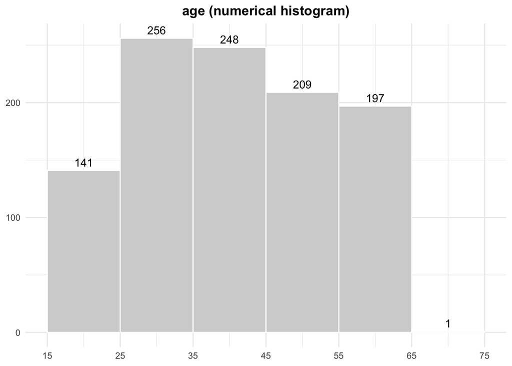

[figure not shown]

```r
ggplot(df) +
  aes(x = age) +
  geom_histogram(binwidth=10, color = "white", fill = "lightgrey") +
  scale_x_continuous(breaks = seq(15, 75, by = 10), lim = c(15, 75)) +
  geom_text(stat = "bin", binwidth = 10, aes(label = after_stat(count)), vjust = -0.5) +
  theme_minimal() +
  ggtitle("age (numerical histogram)") +
  theme(
    plot.title = element_text(face = "bold", hjust = .5),
    axis.title = element_blank()
  )
```

```r
create_barplot <- function(data, column, size){
p <- ggplot(data) +
  aes(x = .data[[column]]) +
  geom_bar(color = "white", fill = "lightgrey") +
  geom_text(aes(label = after_stat(count)), stat = "count", vjust = -0.5, size = size) +
  theme_minimal() +
  ggtitle(column) +
  theme(
    plot.title = element_text(face = "bold", hjust = .5),
    axis.title = element_blank()
  )
}
```

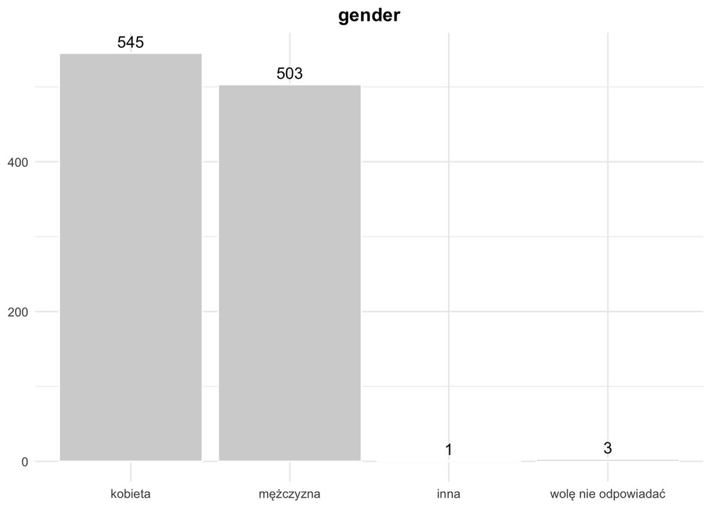

```r
print(create_barplot(df, "gender", 4))
```

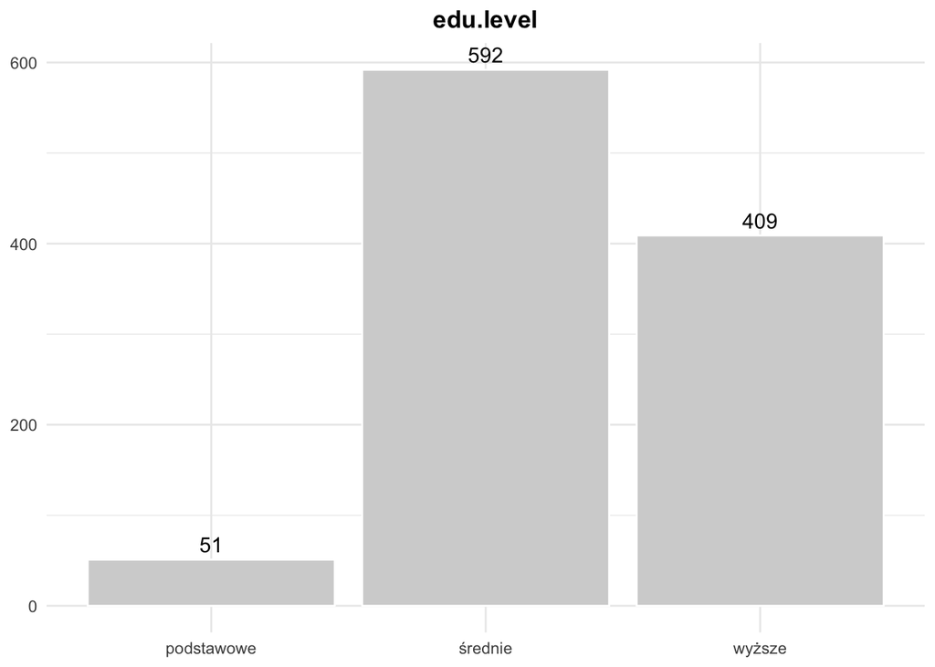

```r
print(create_barplot(df, "edu.level", 4))
```

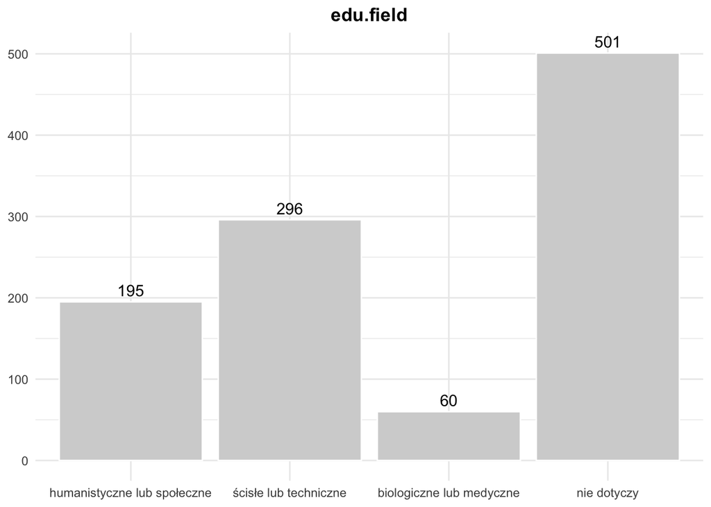

```r
print(create_barplot(df, "edu.field", 4))
```

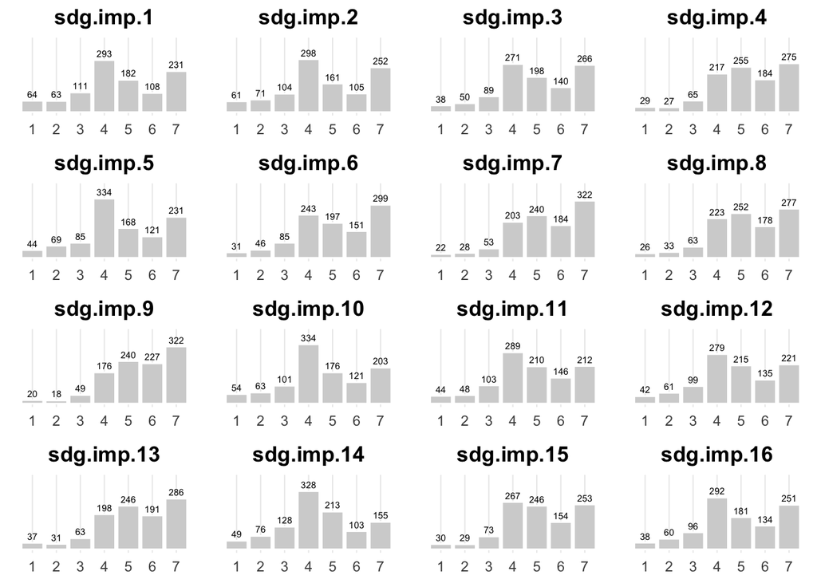

```r
plots <- list()
for(i in 1:16){
  col = glue::glue("sdg.imp.{i}")
  plots[[i]] <- create_barplot(df, col, 2) +
    scale_x_continuous(breaks = seq(1, 7, by = 1)) +
    ylim(0, 400) +
    theme(
      axis.text.y = element_blank(),
      panel.grid = element_line(linewidth=.35),
      panel.grid.major.y = element_blank(),
      panel.grid.minor = element_blank())
}

gridExtra::grid.arrange(
  grobs = plots,
  nrow = 4,
  ncol = 4,
)
```

### 2) różnic średnich w grupach (np. test T

```r
df <- df %>%
  # z gory przepraszam osoby niebinarne
  filter(gender %in% c("kobieta", "mężczyzna"))
```

```r
# troche bez sensu ta analiza bo nie mam pojecia czym sa te zmienne sdg.imp.3
# wiec jak mam wyciagac jakies wnioski albo szukac polaczen/zaleznosci
t.test(age ~ gender, data = df)
```

```
##
##  Welch Two Sample t-test
##
## data:  age by gender
## t = -1.5547, df = 1038.1, p-value = 0.1203
## alternative hypothesis: true difference in means between group kobieta and group mężczyzna is not equal to 0
## 95 percent confidence interval:
##  -2.8058853  0.3251951
## sample estimates:
##   mean in group kobieta mean in group mężczyzna
##                40.61651                41.85686
```

```r
t.test(sdg.imp.3 ~ gender, data = df)
```

```
##
##  Welch Two Sample t-test
##
## data:  sdg.imp.3 by gender
## t = 0.0030996, df = 1042.3, p-value = 0.9975
## alternative hypothesis: true difference in means between group kobieta and group mężczyzna is not equal to 0
## 95 percent confidence interval:
##  -0.2005897  0.2012244
## sample estimates:
##   mean in group kobieta mean in group mężczyzna
##                4.924771                4.924453
```

### ANOVA)

```r
anova_result <- aov(sdg.imp.3 ~ ., data = df)
summary(anova_result)
```

```
##               Df Sum Sq Mean Sq  F value   Pr(>F)
## age            1    7.1     7.1   12.268 0.000481 ***
## gender         1    0.0     0.0    0.026 0.871605
## edu.level      2    2.3     1.1    1.972 0.139742
## edu.field      3    2.1     0.7    1.198 0.309309
## sdg.imp.1      1 1761.7  1761.7 3042.556  < 2e-16 ***
## sdg.imp.2      1  230.0   230.0  397.300  < 2e-16 ***
## sdg.imp.4      1  189.2   189.2  326.728  < 2e-16 ***
## sdg.imp.5      1   11.8    11.8   20.359 7.16e-06 ***
## sdg.imp.6      1   49.6    49.6   85.668  < 2e-16 ***
## sdg.imp.7      1    2.6     2.6    4.574 0.032688 *
## sdg.imp.8      1    1.3     1.3    2.223 0.136237
## sdg.imp.9      1    5.3     5.3    9.132 0.002574 **
## sdg.imp.10     1    4.4     4.4    7.628 0.005849 **
## sdg.imp.11     1    1.5     1.5    2.675 0.102217
## sdg.imp.12     1    1.0     1.0    1.664 0.197408
## sdg.imp.13     1    0.0     0.0    0.007 0.935097
## sdg.imp.14     1    0.7     0.7    1.171 0.279395
## sdg.imp.15     1    8.4     8.4   14.507 0.000148 ***
## sdg.imp.16     1    0.5     0.5    0.852 0.356291
## Residuals   1025  593.5     0.6
## ---
## Signif. codes:  0 '***' 0.001 '**' 0.01 '*' 0.05 '.' 0.1 ' ' 1
```

### bądź korelacji

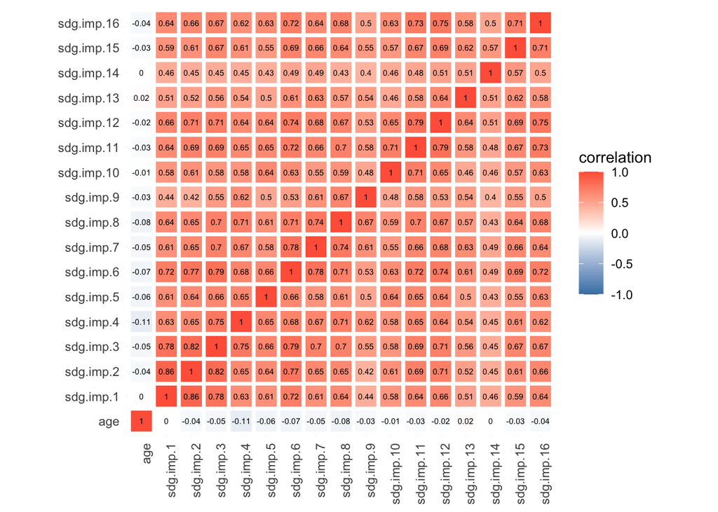

```r
df_numeric <- df %>%
  select(where(is.numeric))
  # select(!age)

df_melted <- reshape2::melt(cor(df_numeric), value.name = "correlation")
ggplot(df_melted) +
  aes(x = Var1, y = Var2, fill = correlation) +
  geom_tile(color = "white",
            lwd = 1.25,
            linetype = 1) +
  coord_fixed() +
  geom_text(aes(label = round(correlation, 2)), size = 2) +
  theme_minimal() +
  scale_fill_gradient2(low = "steelblue", mid = "white", high = "tomato",
                       midpoint = 0, limits = c(-1, 1)) +
  theme(
    axis.title = element_blank(),
    axis.text.x = element_text(angle=90, hjust = 1)
  )
```

### bądź regresji liniowej 2 (max 3) zmiennych

```r
summary(lm(sdg.imp.3 ~ age, data = df))
```

```
##
## Call:
## lm(formula = sdg.imp.3 ~ age, data = df)
##
## Residuals:
##     Min      1Q  Median      3Q     Max
## -4.0472 -0.9722  0.0581  1.9273  2.2208
##
## Coefficients:
##              Estimate Std. Error t value Pr(>|t|)
## (Intercept)  5.187586   0.171134   30.31   <2e-16 ***
## age         -0.006381   0.003963   -1.61    0.108
## ---
## Signif. codes:  0 '***' 0.001 '**' 0.01 '*' 0.05 '.' 0.1 ' ' 1
##
## Residual standard error: 1.655 on 1046 degrees of freedom
## Multiple R-squared:  0.002473,   Adjusted R-squared:  0.001519
## F-statistic: 2.593 on 1 and 1046 DF,  p-value: 0.1077
```

### 3) zależności w formie wykresu rozrzutu

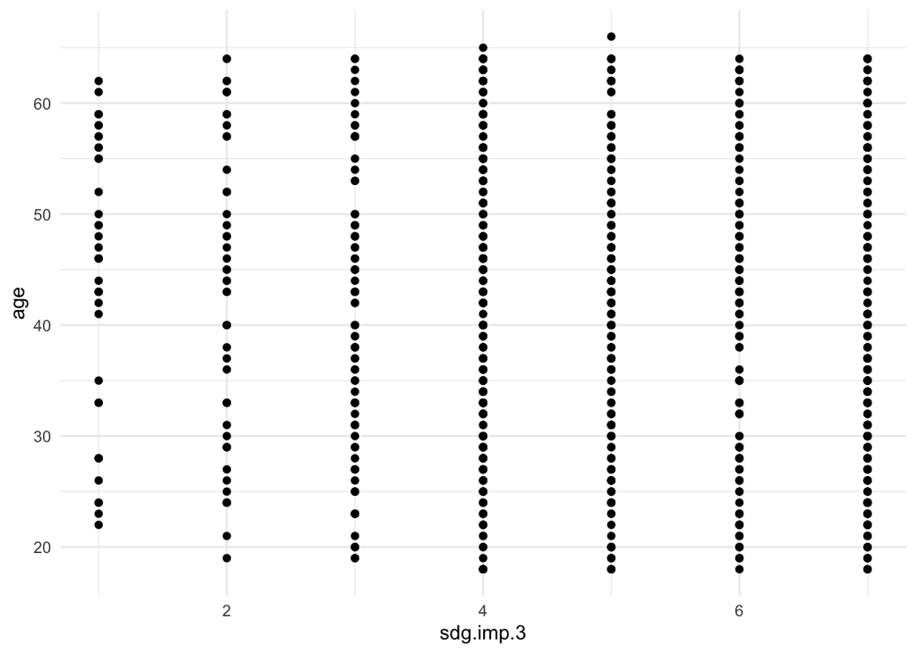

```r
ggplot(df) +
  aes(x = sdg.imp.3, y = age) +
  geom_point() +
  theme_minimal()
```

## e) zapisz w raporcie rmarkdown interpretację analityczną wyników (komentarz analityczny)

### Statystyki opisowe

Analizując rozkład zmiennej age, widzimy, że średnia wieku respondentów wynosi **41,19** lat, a mediana **41** lat. Minimalna wartość to **18**, a maksymalna **66**. Wartości kwartylowe (Q1 i Q3) wynoszą odpowiednio **30** i **52** lata, co wskazuje na dość szeroki rozrzut danych.

### Analiza różnic średnich

#### Porównanie wieku według płci

Test t-studenta dla zmiennej `age` w podziale na płeć wykazał brak istotnej różnicy między średnią wieku kobiet **(40,62)** i mężczyzn **(41,86)**. Wartość p wynosi **0,1203**, co oznacza, że różnica nie jest statystycznie istotna.

#### Różnice w ocenie sdg.imp.3 według płci

Podobnie, analiza `sdg.imp.3` według płci nie wykazała istotnych różnic **(p = 0,9975)**. Średnie dla kobiet i mężczyzn są niemal identyczne **(4,92)**.

#### Analiza zależności i regresja

Regresja liniowa między zmienną `sdg.imp.3` a age wykazała brak istotnej zależności **(p = 0,1077)**. Wartość współczynnika regresji wynosi **-0,0064**, co sugeruje minimalny i nieistotny spadek oceny w zależności od wieku.

### Wnioski

Brak istotnych różnic w poziomie istotności przypisywanej `sdg.imp.3` w zależności od płci.

## f) użyj odpowiedniego formatowania:

### - nagłówki 2 lub 3 stopnia dla 3 analiz

### - przywoływane w interpretacji nazwy zmiennych wyróżnione opcją `verbatim` lub kursywą

### - przywoływane w interpretacji wartości liczbowe pogrubione

## g) po skończonej pracy wyniki umieść w katalogu z zajęć nr 3 na Teams

POZIOMY ZMIENNYCH:

`gender`: 1) kobieta 2) mężczyzna 3) inna 4) wolę nie odpowiadać

`edu.level` (PL): 1) podstawowe 2) średnie 3) wyższe

`edu.field` (wykształcenie kierunkowe): 1) humanistyczne lub społeczne 2) ścisłe lub techniczne 3) biologiczne lub medyczne 4) nie dotyczy